```python
import pandas as pd
import numpy as np
import warnings
warnings.filterwarnings("ignore")
```

- 这个数据是从Kaggle获取的，因为这类数据都算是涉密数据，所以下载的数据并不是原始数据

```python
data = pd.read_csv("C:/Users/zhang/Desktop/creditcardfraud/creditcard.csv")
```

```python
len(data)
```

```
284807
```

- 数据一共有284807条

```python
data.columns
```

```
Index(['Time', 'V1', 'V2', 'V3', 'V4', 'V5', 'V6', 'V7', 'V8', 'V9', 'V10',
       'V11', 'V12', 'V13', 'V14', 'V15', 'V16', 'V17', 'V18', 'V19', 'V20',
       'V21', 'V22', 'V23', 'V24', 'V25', 'V26', 'V27', 'V28', 'Amount',
       'Class'],
      dtype='object')
```

```python
len(data.columns)
```

```
31
```

```python
set(data.Class)
```

```
{0, 1}
```

- 上面是数据中各列的特征名称，一共有31个特征，但是由于隐私的原因，并没有公开显示真实的含义是什么，而是只通过V+数字的形式来表示
- 数据中对应的目标变量是Class，只有两种结果，0和1，其中1对应的是欺诈记录，而0对应的是非欺诈记录

下面统计了各特征值的缺失情况

```python
(data.isnull().sum())/len(data)
```

```
Time      0.0
V1        0.0
V2        0.0
V3        0.0
V4        0.0
V5        0.0
V6        0.0
V7        0.0
V8        0.0
V9        0.0
V10       0.0
V11       0.0
V12       0.0
V13       0.0
V14       0.0
V15       0.0
V16       0.0
V17       0.0
V18       0.0
V19       0.0
V20       0.0
V21       0.0
V22       0.0
V23       0.0
V24       0.0
V25       0.0
V26       0.0
V27       0.0
V28       0.0
Amount    0.0
Class     0.0
dtype: float64
```

- 不存在缺失的情况

下面先观察每个特征的取值范围，确实是否需要进行归一化的处理

```python
data.describe()
```

|  | Time | V1 | V2 | V3 | V4 | V5 | V6 | V7 | V8 | V9 | ... | V21 | V22 | V23 | V24 | V25 | V26 | V27 | V28 | Amount | Class |
| --- | --- | --- | --- | --- | --- | --- | --- | --- | --- | --- | --- | --- | --- | --- | --- | --- | --- | --- | --- | --- | --- |
| count | 284807.000000 | 2.848070e+05 | 2.848070e+05 | 2.848070e+05 | 2.848070e+05 | 2.848070e+05 | 2.848070e+05 | 2.848070e+05 | 2.848070e+05 | 2.848070e+05 | ... | 2.848070e+05 | 2.848070e+05 | 2.848070e+05 | 2.848070e+05 | 2.848070e+05 | 2.848070e+05 | 2.848070e+05 | 2.848070e+05 | 284807.000000 | 284807.000000 |
| mean | 94813.859575 | 3.919560e-15 | 5.688174e-16 | -8.769071e-15 | 2.782312e-15 | -1.552563e-15 | 2.010663e-15 | -1.694249e-15 | -1.927028e-16 | -3.137024e-15 | ... | 1.537294e-16 | 7.959909e-16 | 5.367590e-16 | 4.458112e-15 | 1.453003e-15 | 1.699104e-15 | -3.660161e-16 | -1.206049e-16 | 88.349619 | 0.001727 |
| std | 47488.145955 | 1.958696e+00 | 1.651309e+00 | 1.516255e+00 | 1.415869e+00 | 1.380247e+00 | 1.332271e+00 | 1.237094e+00 | 1.194353e+00 | 1.098632e+00 | ... | 7.345240e-01 | 7.257016e-01 | 6.244603e-01 | 6.056471e-01 | 5.212781e-01 | 4.822270e-01 | 4.036325e-01 | 3.300833e-01 | 250.120109 | 0.041527 |
| min | 0.000000 | -5.640751e+01 | -7.271573e+01 | -4.832559e+01 | -5.683171e+00 | -1.137433e+02 | -2.616051e+01 | -4.355724e+01 | -7.321672e+01 | -1.343407e+01 | ... | -3.483038e+01 | -1.093314e+01 | -4.480774e+01 | -2.836627e+00 | -1.029540e+01 | -2.604551e+00 | -2.256568e+01 | -1.543008e+01 | 0.000000 | 0.000000 |
| 25% | 54201.500000 | -9.203734e-01 | -5.985499e-01 | -8.903648e-01 | -8.486401e-01 | -6.915971e-01 | -7.682956e-01 | -5.540759e-01 | -2.086297e-01 | -6.430976e-01 | ... | -2.283949e-01 | -5.423504e-01 | -1.618463e-01 | -3.545861e-01 | -3.171451e-01 | -3.269839e-01 | -7.083953e-02 | -5.295979e-02 | 5.600000 | 0.000000 |
| 50% | 84692.000000 | 1.810880e-02 | 6.548556e-02 | 1.798463e-01 | -1.984653e-02 | -5.433583e-02 | -2.741871e-01 | 4.010308e-02 | 2.235804e-02 | -5.142873e-02 | ... | -2.945017e-02 | 6.781943e-03 | -1.119293e-02 | 4.097606e-02 | 1.659350e-02 | -5.213911e-02 | 1.342146e-03 | 1.124383e-02 | 22.000000 | 0.000000 |
| 75% | 139320.500000 | 1.315642e+00 | 8.037239e-01 | 1.027196e+00 | 7.433413e-01 | 6.119264e-01 | 3.985649e-01 | 5.704361e-01 | 3.273459e-01 | 5.971390e-01 | ... | 1.863772e-01 | 5.285536e-01 | 1.476421e-01 | 4.395266e-01 | 3.507156e-01 | 2.409522e-01 | 9.104512e-02 | 7.827995e-02 | 77.165000 | 0.000000 |
| max | 172792.000000 | 2.454930e+00 | 2.205773e+01 | 9.382558e+00 | 1.687534e+01 | 3.480167e+01 | 7.330163e+01 | 1.205895e+02 | 2.000721e+01 | 1.559499e+01 | ... | 2.720284e+01 | 1.050309e+01 | 2.252841e+01 | 4.584549e+00 | 7.519589e+00 | 3.517346e+00 | 3.161220e+01 | 3.384781e+01 | 25691.160000 | 1.000000 |

8 rows × 31 columns

- 从上面的结果可以看出，特征从V1-V28的取值范围都是比较相近的，且取值都很小，但是Time和Amount这两个特征对应的值与其他特征值的差距就很大，所以应该对其进行归一化的处理，并且归一化也可以很好的防止异常值的出现

```python
#不受异常值的影响的一种归一化方法
from sklearn.preprocessing import RobustScaler

#标准化处理
rs_scaler = RobustScaler()
data['scaler_amount'] = rs_scaler.fit_transform(data['Amount'].values.reshape(-1,1))
data['scaler_time'] = rs_scaler.fit_transform(data['Time'].values.reshape(-1,1))
```

```python
#删除原有的Amount和Time
data.drop(['Amount','Time'],axis=1,inplace=True)
```

```python
print("欺诈比例：",round(sum(data.Class == 1)/len(data) * 100,2),"%")
print("非欺诈比例：",round(sum(data.Class == 0)/len(data) * 100,2),"%")
```

```
欺诈比例： 0.17 %
非欺诈比例： 99.83 %
```

- 非欺诈记录占99.83%，而欺诈记录只占0.17%，说明这是一个非常不平衡的数据，两类数据的数量差距非常大
- 我的目的是训练出一个可以识别欺诈交易的模型，但是这个数据中有很多的非欺诈数据，所以模型会更关注非欺诈数据，那么在识别欺诈数据时就不会准确了
- 所以如何处理不平衡数据就显得非常重要了

```python
from sklearn.model_selection import StratifiedShuffleSplit
```

```python
X = data.drop('Class',axis=1)
y = data['Class']

#获取数据
s = StratifiedShuffleSplit(n_splits=5,random_state=None)

for train_index,test_index in s.split(X,y):
    X_train,X_test = X.iloc[train_index],X.iloc[test_index]
    y_train,y_test = y.iloc[train_index],y.iloc[test_index]

X_train = X_train.values
X_test = X_test.values
y_train = y_train.values
y_test = y_test.values
```

下面使用欠采样的方式获取数据

```python
#随机打乱
data = data.sample(frac=1)
fraud_data = data.loc[data.Class == 1]
non_fraud_data = data.loc[data.Class == 0][:492]

#组成出平衡数据
new_data = pd.concat([fraud_data,non_fraud_data])
new_data = new_data.sample(frac=1,random_state=42)
```

```python
print(new_data['Class'].value_counts()/len(new_data))
```

```
1    0.5
0    0.5
Name: Class, dtype: float64
```

- 上面是使用了一种最普通的欠采样的方式来获取一个平衡数据，这种方式是删除多余的数据来达到平衡
- 重新采样之后的数据符合了平衡数据的标准
- 现在有了一个平衡数据后就可以将重心放在选择合适的特征上了
- 为了构建一个可以预测欺诈行为的模型，应该筛选一下哪些特征与欺诈行为之间的相关性更高

下面通过箱型图的方式找出哪些特征与目标变量之间是有关系的

```python
import matplotlib.pyplot as plt
import seaborn as sns
```

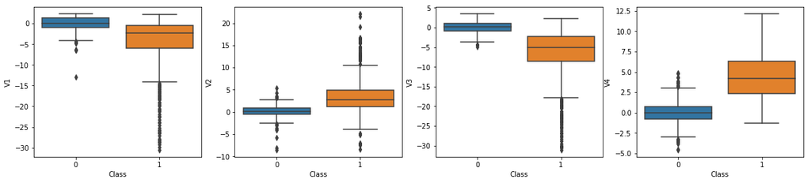

```python
f,axes = plt.subplots(ncols=4,figsize=(20,4))

sns.boxplot(x='Class',y='V1',data=new_data,ax=axes[0])
sns.boxplot(x='Class',y='V2',data=new_data,ax=axes[1])
sns.boxplot(x='Class',y='V3',data=new_data,ax=axes[2])
sns.boxplot(x='Class',y='V4',data=new_data,ax=axes[3])
```

- 从上面这四个特征可以看出，当V1和V3的值越低时，则越有可能是欺诈行为；而V2和V4的值是越高则越有可能是欺诈行为

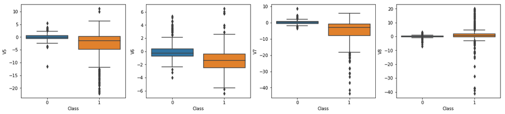

```python
f,axes = plt.subplots(ncols=4,figsize=(20,4))

sns.boxplot(x='Class',y='V5',data=new_data,ax=axes[0])
sns.boxplot(x='Class',y='V6',data=new_data,ax=axes[1])
sns.boxplot(x='Class',y='V7',data=new_data,ax=axes[2])
sns.boxplot(x='Class',y='V8',data=new_data,ax=axes[3])
```

- 从上面这四个特征可以看出，当V5、V6和V7的值越低时，则越有可能是欺诈行为；而V8与欺诈行为的关系不明显

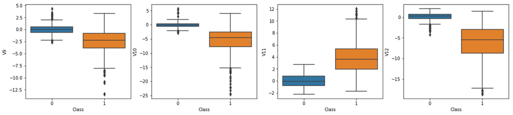

```python
f,axes = plt.subplots(ncols=4,figsize=(20,4))

sns.boxplot(x='Class',y='V9',data=new_data,ax=axes[0])
sns.boxplot(x='Class',y='V10',data=new_data,ax=axes[1])
sns.boxplot(x='Class',y='V11',data=new_data,ax=axes[2])
sns.boxplot(x='Class',y='V12',data=new_data,ax=axes[3])
```

- 从上面这四个特征可以看出，当V9、V10和V12的值越低时，则越有可能是欺诈行为；而V11的值是越高则越有可能是欺诈行为

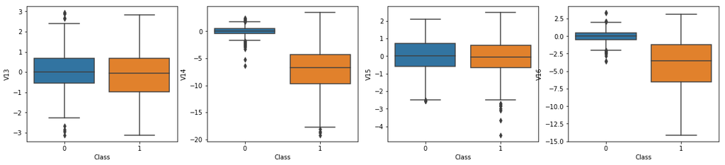

```python
f,axes = plt.subplots(ncols=4,figsize=(20,4))

sns.boxplot(x='Class',y='V13',data=new_data,ax=axes[0])
sns.boxplot(x='Class',y='V14',data=new_data,ax=axes[1])
sns.boxplot(x='Class',y='V15',data=new_data,ax=axes[2])
sns.boxplot(x='Class',y='V16',data=new_data,ax=axes[3])
```

- 从上面这四个特征可以看出，当V14和V16的值越低时，则越有可能是欺诈行为；而V13和V15与欺诈行为关系不明显

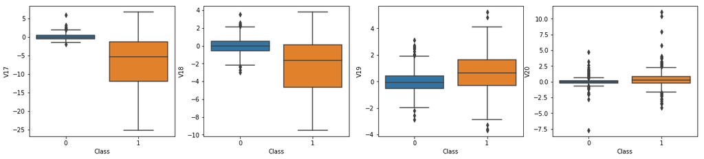

```python
f,axes = plt.subplots(ncols=4,figsize=(20,4))

sns.boxplot(x='Class',y='V17',data=new_data,ax=axes[0])
sns.boxplot(x='Class',y='V18',data=new_data,ax=axes[1])
sns.boxplot(x='Class',y='V19',data=new_data,ax=axes[2])
sns.boxplot(x='Class',y='V20',data=new_data,ax=axes[3])
```

- 从上面这四个特征可以看出，当V17和V18的值越低时，则越有可能是欺诈行为；而V19的值是越高则越有可能是欺诈行为，而V20与欺诈行为关系不明显

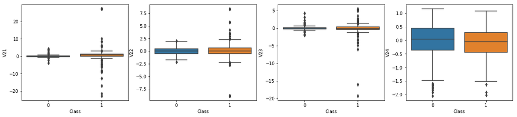

```python
f,axes = plt.subplots(ncols=4,figsize=(20,4))

sns.boxplot(x='Class',y='V21',data=new_data,ax=axes[0])
sns.boxplot(x='Class',y='V22',data=new_data,ax=axes[1])
sns.boxplot(x='Class',y='V23',data=new_data,ax=axes[2])
sns.boxplot(x='Class',y='V24',data=new_data,ax=axes[3])
```

- 上面这四个特征与欺诈行为的关系都不明显

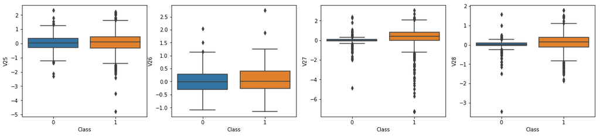

```python
f,axes = plt.subplots(ncols=4,figsize=(20,4))

sns.boxplot(x='Class',y='V25',data=new_data,ax=axes[0])
sns.boxplot(x='Class',y='V26',data=new_data,ax=axes[1])
sns.boxplot(x='Class',y='V27',data=new_data,ax=axes[2])
sns.boxplot(x='Class',y='V28',data=new_data,ax=axes[3])
```

- 上面这四个特征与欺诈行为的关系依然不明显

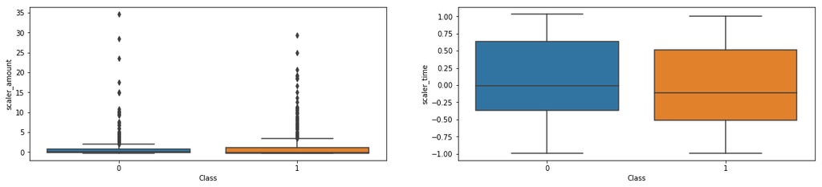

```python
f,axes = plt.subplots(ncols=2,figsize=(20,4))

sns.boxplot(x='Class',y='scaler_amount',data=new_data,ax=axes[0])
sns.boxplot(x='Class',y='scaler_time',data=new_data,ax=axes[1])
```

- 上面这两个特征对于判断是否是欺诈行为也是不明显的
- 所以，与欺诈相关性比较高的特征有V1、V2、V3、V4、V5、V6、V7、V9、V10、V11、V12、V14、V16、V17、V18和V19这16个特征
- 从上面可视化的结果可以看出，大多数特征的箱型图中都可以看出是含有异常值的，所以下面要先定义一个规则来将异常值去掉，否则异常值会影响模型的准确性

下面针对上面提到的16个特征进行异常值的剔除

```python
from scipy.stats import norm
```

```python
#定义异常值移除函数
def remove_outliers(column,data):
    v = data[column].loc[data['Class'] == 1].values
    q25 = np.percentile(v,25)
    q75 = np.percentile(v,75)

    v_lower = q25 - (q75 - q25) * 1.5
    v_upper = q75 + (q75 - q25) * 1.5

    new_data = data.drop(data.loc[(data[column] < v_lower) | (data[column] > v_upper)].index)
    return new_data
```

```python
#分布图
def draw(data,column):
    f,ax = plt.subplots(1,figsize=(5,5))
    v = data[column].loc[data['Class'] == 1].values
    sns.distplot(v,ax=ax,fit=norm)
    ax.set_title(column)
```

V1

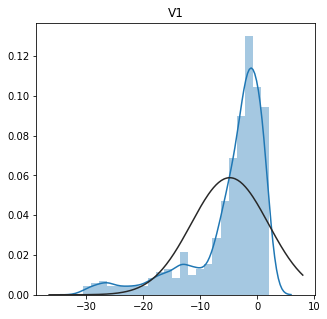

```python
draw(new_data,'V1')
```

- 上图可以看出V1有严重的偏移，很不符合正态分布，有很多偏小的异常值出现

```python
new_data = remove_outliers('V1',new_data)
```

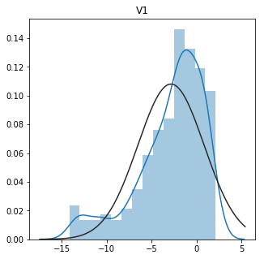

```python
draw(new_data,'V1')
```

- 剔除异常值以后，数据更规整，更符合正态分布

V2

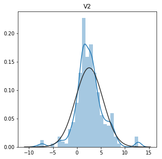

```python
draw(new_data,'V2')
```

- V2两端都有异常情况出现

```python
new_data = remove_outliers('V2',new_data)
```

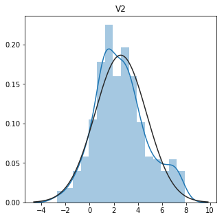

```python
draw(new_data,'V2')
```

V3

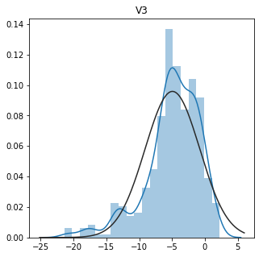

```python
draw(new_data,'V3')
```

- V3中有很多过小的异常值

```python
new_data = remove_outliers('V3',new_data)
```

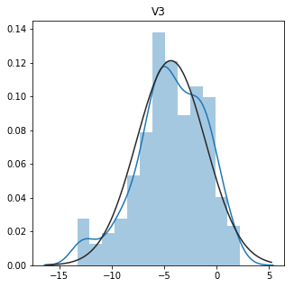

```python
draw(new_data,'V3')
```

V4

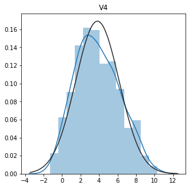

```python
draw(new_data,'V4')
```

- 从箱型图和分布图来看，这个特征的异常值并不明显，所以可以不进行处理

V5

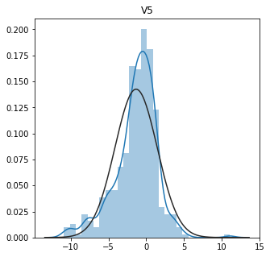

```python
draw(new_data,'V5')
```

- V5特征存在异常值

```python
new_data = remove_outliers('V5',new_data)
```

V6

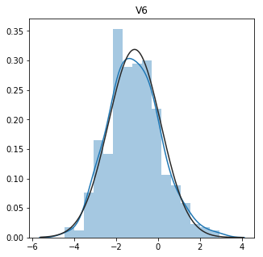

```python
draw(new_data,'V6')
```

- V6存在异常值

```python
new_data = remove_outliers('V6',new_data)
```

V7

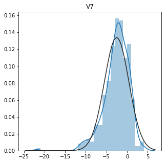

```python
draw(new_data,'V7')
```

- V7存在异常值

```python
new_data = remove_outliers('V7',new_data)
```

V9

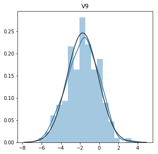

```python
draw(new_data,'V9')
```

- V9存在异常值

```python
new_data = remove_outliers('V9',new_data)
```

V10

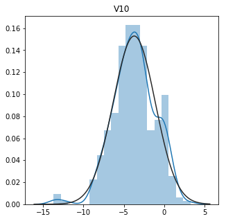

```python
draw(new_data,'V10')
```

- V10存在异常值

```python
new_data = remove_outliers('V10',new_data)
```

V11

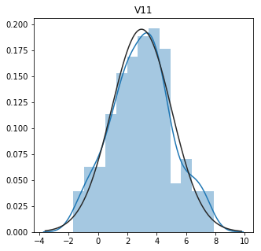

```python
draw(new_data,'V11')
```

```python
new_data = remove_outliers('V11',new_data)
```

V12

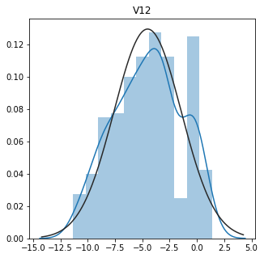

```python
draw(new_data,'V12')
```

```python
new_data = remove_outliers('V12',new_data)
```

V13

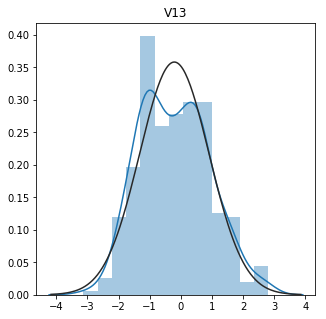

```python
draw(new_data,'V13')
```

```python
new_data = remove_outliers('V13',new_data)
```

V14

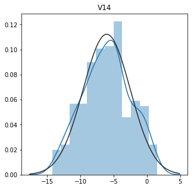

```python
draw(new_data,'V14')
```

```python
new_data = remove_outliers('V14',new_data)
```

V16

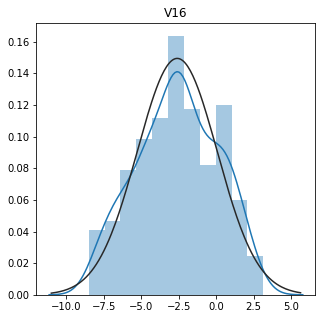

```python
draw(new_data,'V16')
```

```python
new_data = remove_outliers('V16',new_data)
```

V17

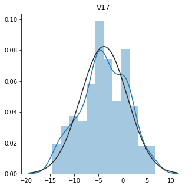

```python
draw(new_data,'V17')
```

```python
new_data = remove_outliers('V17',new_data)
```

V18

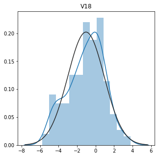

```python
draw(new_data,'V18')
```

```python
new_data = remove_outliers('V18',new_data)
```

V19

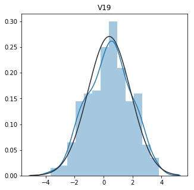

```python
draw(new_data,'V19')
```

```python
new_data = remove_outliers('V19',new_data)
```

- 到这里所有特征的异常值就处理结束了，但是对于异常值的惩罚系数还可以根据后面的结果进行调整

```python
from sklearn.model_selection import train_test_split
from sklearn.model_selection import cross_val_score
```

```python
from sklearn.linear_model import LogisticRegression
from sklearn.svm import SVC
from sklearn.neighbors import KNeighborsClassifier
from sklearn.tree import DecisionTreeClassifier
from sklearn.ensemble import RandomForestClassifier
```

```python
X = new_data.drop('Class',axis=1)
y = new_data['Class']
```

```python
new_X_train,new_X_test,new_y_train,new_y_test = train_test_split(X, y, test_size=0.2, random_state=42)

new_X_train = new_X_train.values
new_X_test = new_X_test.values
new_y_train = new_y_train.values
new_y_test = new_y_test.values
```

```python
classifier = {"LR":LogisticRegression(),
             "KNN":KNeighborsClassifier(),
             "SVC":SVC(),
             "DTC":DecisionTreeClassifier()
             }
```

```python
from sklearn.model_selection import cross_val_score


for key,classifier in classifier.items():
    classifier.fit(new_X_train,new_y_train)
    training_score = cross_val_score(classifier,new_X_train,new_y_train, cv=5)
    print("Classifiers: ", classifier.__class__.__name__,round(training_score.mean(), 2) * 100, "% accuracy score")
```

```
Classifiers:  LogisticRegression 94.0 % accuracy score
Classifiers:  KNeighborsClassifier 93.0 % accuracy score
Classifiers:  SVC 93.0 % accuracy score
Classifiers:  DecisionTreeClassifier 91.0 % accuracy score
```

```python
from sklearn.model_selection import GridSearchCV
```

```python
#lr_gird
lr_params = {"penalty":['l1','l2'],'C':[0.001,0.01,0.1,1,10,100,1000]}
grid_lr = GridSearchCV(LogisticRegression(),lr_params)
grid_lr.fit(new_X_train,new_y_train)
log_lr = grid_lr.best_estimator_
lr_score = cross_val_score(log_lr,new_X_train,new_y_train,cv=5)
print("LR accuracy:",round(lr_score.mean() * 100,2).astype(str)+"%")

#knn_gird
knn_params = {"n_neighbors":list(range(2,5,1)),'algorithm':['auto','ball_tree','kd_tree','brute']}
grid_knn = GridSearchCV(KNeighborsClassifier(),knn_params)
grid_knn.fit(new_X_train,new_y_train)
log_knn = grid_knn.best_estimator_
knn_score = cross_val_score(log_knn,new_X_train,new_y_train,cv=5)
print("KNN Accuracy:",round(knn_score.mean() * 100,2).astype(str) + '%')

#svc_grid
svc_params = {'C':[0.5,0.7,0.9,1],'kernel':['rbf','poly','sigmoid','linear']}
grid_svc = GridSearchCV(SVC(),svc_params)
grid_svc.fit(new_X_train,new_y_train)
log_svc = grid_svc.best_estimator_
svc_socre = cross_val_score(log_svc,new_X_train,new_y_train,cv=5)
print("SVC Accuracy:",round(svc_socre.mean() * 100,2).astype(str)+'%')

#tree_grid
tree_params = {"criterion":['gini','entropy'],"max_depth":list(range(2,4,1)),"min_samples_leaf":list(range(5,7,1))}
grid_tree = GridSearchCV(DecisionTreeClassifier(),tree_params)
grid_tree.fit(new_X_train,new_y_train)
log_tree = grid_tree.best_estimator_
tree_socre = cross_val_score(log_tree,new_X_train,new_y_train,cv=5)
print("Tree Accuracy:",round(tree_socre.mean() * 100,2).astype(str)+'%')
```

```
LR accuracy: 94.13%
KNN Accuracy: 93.03%
SVC Accuracy: 94.29%
Tree Accuracy: 91.44%
```

- 上面准确率最高的是SVC模型，而LR模型的准确率也很高

下面导入两种处理不平衡数据的方法

```python
from imblearn.over_sampling import SMOTE
from imblearn.under_sampling import NearMiss
from imblearn.pipeline import make_pipeline
from sklearn.metrics import precision_score,recall_score,f1_score,roc_auc_score,accuracy_score,classification_report
```

下面使用NearMiss对数据进行重新采样

```python
undersample_X = data.drop('Class',axis=1)
undersample_y = data['Class']

for train_index,test_index in s.split(undersample_X,undersample_y):
    undersample_X_train,undersample_X_test = undersample_X.iloc[train_index],undersample_X.iloc[test_index]
    undersample_y_train,undersample_y_test = undersample_y.iloc[train_index],undersample_y.iloc[test_index]

undersample_X_train = undersample_X_train.values
undersample_X_test = undersample_X_test.values
undersample_y_train = undersample_y_train.values
undersample_y_test = undersample_y_test.values

undersample_acc = []
undersample_pre = []
undersample_recall = []
undersample_f1 = []
undersample_auc = []

#输出KNN模型对应的各项指标
for train_index,test_index in s.split(undersample_X_train,undersample_y_train):
    undersample_pipeline = make_pipeline(NearMiss(sampling_strategy='majority'),log_lr)
    undersample_m = undersample_pipeline.fit(undersample_X_train[train_index],undersample_y_train[train_index])
    undersample_prediction = undersample_m.predict(undersample_X_train[test_index])
    undersample_acc.append(undersample_pipeline.score(X_train[test_index],y_train[test_index]))
    undersample_pre.append(precision_score(y_train[test_index],undersample_prediction))
    undersample_recall.append(recall_score(y_train[test_index],undersample_prediction))
    undersample_f1.append(f1_score(y_train[test_index],undersample_prediction))
    undersample_auc.append(roc_auc_score(y_train[test_index],undersample_prediction))
```

使用交叉验证的方式进行预测

```python
from sklearn.metrics import roc_curve
from sklearn.model_selection import cross_val_predict
```

```python
#使用原始数据来评估模型的好坏
lr_predct = cross_val_predict(log_lr,new_X_train,new_y_train,cv=5,method='decision_function')

knn_predict = cross_val_predict(log_knn,new_X_train,new_y_train,cv=5)

svc_predict = cross_val_predict(log_svc,new_X_train,new_y_train,cv=5,method='decision_function')

tree_predict = cross_val_predict(log_tree,new_X_train,new_y_train,cv=5)
```

输出AUC面积，越大越好

```python
from sklearn.metrics import roc_auc_score

print("lr roc_auc:",roc_auc_score(new_y_train,lr_predct))
print("knn roc_auc:",roc_auc_score(new_y_train,knn_predict))
print("svc roc_auc:",roc_auc_score(new_y_train,svc_predict))
print("tree roc_auc:",roc_auc_score(new_y_train,tree_predict))
```

```
lr roc_auc: 0.9751647905891897
knn roc_auc: 0.9249721123618295
svc roc_auc: 0.971909542642734
tree roc_auc: 0.911555623161951
```

- 根据AUC面积来看，分类效果最好的是LR模型

使用ROC评估模型

```python
#计算ROC曲线的相关参数
lr_fpr,lr_tpr,lr_thresold = roc_curve(new_y_train,lr_predct)
knn_fpr,knn_tpr,knn_thresold = roc_curve(new_y_train,knn_predict)
svc_fpr,svc_tpr,svc_thresold = roc_curve(new_y_train,svc_predict)
tree_fpr,tree_tpr,tree_thresold = roc_curve(new_y_train,tree_predict)
```

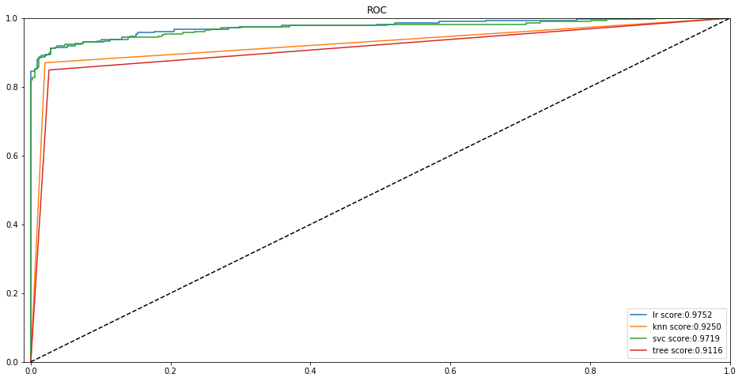

```python
plt.figure(figsize=(16,8))
plt.title("ROC")
plt.plot(lr_fpr,lr_tpr,label='lr score:{:.4f}'.format(roc_auc_score(new_y_train,lr_predct)))
plt.plot(knn_fpr,knn_tpr,label='knn score:{:.4f}'.format(roc_auc_score(new_y_train,knn_predict)))
plt.plot(svc_fpr,svc_tpr,label='svc score:{:.4f}'.format(roc_auc_score(new_y_train,svc_predict)))
plt.plot(tree_fpr,tree_tpr,label='tree score:{:.4f}'.format(roc_auc_score(new_y_train,tree_predict)))
plt.plot([0, 1], [0, 1], 'k--')
plt.axis([-0.01, 1, 0, 1])
plt.legend()
```

- 上面是不同模型对应的ROC曲线，这个曲线越接近左上角则代表就越好，而上面最好的是LR模型

使用精确率、召回率和F1指标评估LR模型

```python
from sklearn.metrics import precision_recall_curve

precision,recall,threshold = precision_recall_curve(new_y_train,lr_predct)
```

```python
from sklearn.metrics import recall_score,precision_score,f1_score,accuracy_score
y_pred = log_lr.predict(new_X_test)

print('Recall Score: {:.2f}'.format(recall_score(new_y_test, y_pred)))
print('Precision Score: {:.2f}'.format(precision_score(new_y_test, y_pred)))
print('F1 Score: {:.2f}'.format(f1_score(new_y_test, y_pred)))
print('Accuracy Score: {:.2f}'.format(accuracy_score(new_y_test, y_pred)))

print('---' * 45)

print("Recall Average Score: {:.2f}".format(np.mean(undersample_recall)))
print("Precision Average Score: {:.2f}".format(np.mean(undersample_pre)))
print("F1 Average Score: {:.2f}".format(np.mean(undersample_f1)))
print("Accuracy Average Score: {:.2f}".format(np.mean(undersample_acc)))
print('---' * 45)
```

```
Recall Score: 0.93
Precision Score: 0.60
F1 Score: 0.73
Accuracy Score: 0.73
---------------------------------------------------------------------------------------------------------------------------------------
Recall Average Score: 0.28
Precision Average Score: 0.00
F1 Average Score: 0.00
Accuracy Average Score: 0.64
---------------------------------------------------------------------------------------------------------------------------------------
```

```python
undersample_y_score = log_lr.decision_function(X_test)

from sklearn.metrics import average_precision_score

#平均精确率
undersample_average_pre = average_precision_score(y_test,undersample_y_score)
print('Average precision-recall score: {0:0.2f}'.format(undersample_average_pre))
```

```
Average precision-recall score: 0.05
```

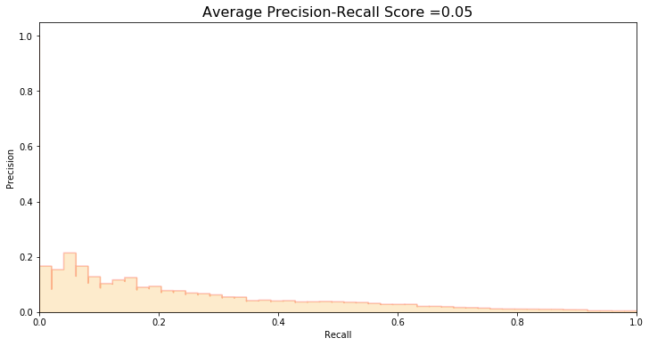

```python
p,r,_ = precision_recall_curve(y_test,undersample_y_score)
fig = plt.figure(figsize=(12,6))

plt.step(r,p,color='r',alpha=0.2,where='post')
plt.fill_between(r,p,step='post',alpha=0.2,color='#F59B00')
plt.xlabel('Recall')
plt.ylabel('Precision')
plt.ylim([0.0, 1.05])
plt.xlim([0.0, 1.0])
plt.title('Average Precision-Recall Score ={0:0.2f}'.format(undersample_average_pre), fontsize=16)
plt.show()
```

上面是使用NearMiss处理过的数据，但是效果并不理想

下面使用SMOTE方法

```python
from sklearn.model_selection import RandomizedSearchCV
```

```python
acc_list = []
pre_list = []
recall_list = []
f1_list = []
auc_list = []

lr_sm = LogisticRegression()

lr_sm_params = {'penalty':['l1','l2'],'C':[0.001,0.01,0.1,1,10,100,1000]}
rand_lr_sm = RandomizedSearchCV(LogisticRegression(),lr_sm_params,n_iter=4)

for train_index,test_index in s.split(X_train,y_train):
    pp = make_pipeline(SMOTE(sampling_strategy='minority'),rand_lr_sm)
    model = pp.fit(X_train[train_index],y_train[train_index])
    best = rand_lr_sm.best_estimator_
    predict = best.predict(X_train[test_index])

    acc_list.append(pp.score(X_train[test_index],y_train[test_index]))
    pre_list.append(precision_score(y_train[test_index],predict))
    recall_list.append(recall_score(y_train[test_index],predict))
    f1_list.append(f1_score(y_train[test_index],predict))
    auc_list.append(roc_auc_score(y_train[test_index],predict))

print("accuracy: {}".format(np.mean(acc_list)))
print("precision: {}".format(np.mean(pre_list)))
print("recall: {}".format(np.mean(recall_list)))
print("f1: {}".format(np.mean(f1_list)))
```

```
accuracy: 0.9747512971560098
precision: 0.05928339235541345
recall: 0.9181818181818182
f1: 0.1113257070753925
```

```python
labels = ['No Fraud', 'Fraud']
smote_prediction = best.predict(X_test)
print(classification_report(y_test, smote_prediction,target_names=labels))
```

```
              precision    recall  f1-score   support

    No Fraud       1.00      0.97      0.99     28432
       Fraud       0.06      0.92      0.11        49

    accuracy                           0.97     28481
   macro avg       0.53      0.95      0.55     28481
weighted avg       1.00      0.97      0.98     28481
```

```python
y_score = best.decision_function(X_test)
```

```python
from sklearn.metrics import average_precision_score

ave_pre = average_precision_score(y_test,y_score)
print("ave_pre_recall score:{:.2f}".format(ave_pre))
```

```
ave_pre_recall score:0.84
```

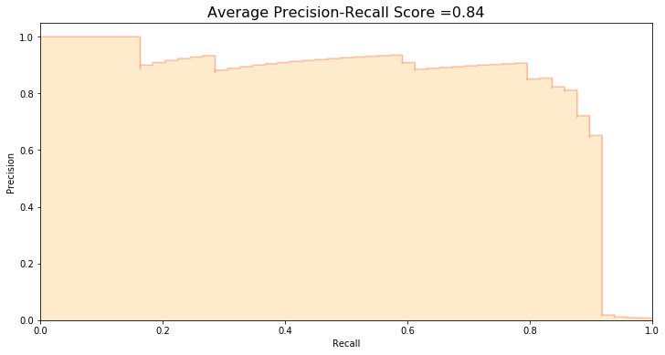

```python
p,r,_ = precision_recall_curve(y_test,y_score)
fig = plt.figure(figsize=(12,6))

plt.step(r,p,color='r',alpha=0.2,where='post')
plt.fill_between(r,p,step='post',alpha=0.2,color='#F59B00')
plt.xlabel('Recall')
plt.ylabel('Precision')
plt.ylim([0.0, 1.05])
plt.xlim([0.0, 1.0])
plt.title('Average Precision-Recall Score ={0:0.2f}'.format(ave_pre), fontsize=16)
```

上面较NearMiss方法来说，平均精确率有所提升

下面使用SMOTE处理原始数据

```python
sm = SMOTE(ratio='minority',random_state=42)

X_sm_train,y_sm_train = sm.fit_sample(X_train,y_train)
```

```python
log_sm = grid_lr.best_estimator_
log_sm.fit(X_sm_train,y_sm_train)
```

```
LogisticRegression(C=1, class_weight=None, dual=False, fit_intercept=True,
                   intercept_scaling=1, l1_ratio=None, max_iter=100,
                   multi_class='warn', n_jobs=None, penalty='l1',
                   random_state=None, solver='warn', tol=0.0001, verbose=0,
                   warm_start=False)
```

```python
from sklearn.metrics import confusion_matrix

#sm
y_pred_sm = log_sm.predict(new_X_test)

#knn
y_pred_knn = log_knn.predict(new_X_test)

#svc
y_pred_svc = log_svc.predict(new_X_test)

#tree
y_pred_tree = log_tree.predict(new_X_test)
```

```python
print('LR:')
print(classification_report(new_y_test, y_pred_sm))
print("-----------------------------------------------------")

print('KNN:')
print(classification_report(new_y_test, y_pred_knn))
print("-----------------------------------------------------")

print('SVC:')
print(classification_report(new_y_test, y_pred_svc))
print("-----------------------------------------------------")

print('TREE:')
print(classification_report(new_y_test, y_pred_tree))
```

```
LR:
              precision    recall  f1-score   support

           0       0.93      0.96      0.94        97
           1       0.93      0.89      0.91        61

    accuracy                           0.93       158
   macro avg       0.93      0.92      0.93       158
weighted avg       0.93      0.93      0.93       158

-----------------------------------------------------
KNN:
              precision    recall  f1-score   support

           0       0.93      0.97      0.95        97
           1       0.95      0.89      0.92        61

    accuracy                           0.94       158
   macro avg       0.94      0.93      0.93       158
weighted avg       0.94      0.94      0.94       158

-----------------------------------------------------
SVC:
              precision    recall  f1-score   support

           0       0.93      0.96      0.94        97
           1       0.93      0.89      0.91        61

    accuracy                           0.93       158
   macro avg       0.93      0.92      0.93       158
weighted avg       0.93      0.93      0.93       158

-----------------------------------------------------
TREE:
              precision    recall  f1-score   support

           0       0.92      0.93      0.92        97
           1       0.88      0.87      0.88        61

    accuracy                           0.91       158
   macro avg       0.90      0.90      0.90       158
weighted avg       0.90      0.91      0.90       158
```

```python
# Final Score in the test set of logistic regression
from sklearn.metrics import accuracy_score

# Logistic Regression with Under-Sampling
y_pred = log_sm.predict(new_X_test)
undersample_score = accuracy_score(new_y_test, y_pred)


# Logistic Regression with SMOTE Technique (Better accuracy with SMOTE t)
y_pred_sm = best.predict(X_test)
oversample_score = accuracy_score(y_test, y_pred_sm)


d = {'Technique': ['Random UnderSampling', 'Oversampling (SMOTE)'], 'Score': [undersample_score, oversample_score]}
final_df = pd.DataFrame(data=d)

# Move column
score = final_df['Score']
final_df.drop('Score', axis=1, inplace=True)
final_df.insert(1, 'Score', score)

# Note how high is accuracy score it can be misleading!
final_df
```

|  | Technique | Score |
| --- | --- | --- |
| 0 | Random UnderSampling | 0.93038 |
| 1 | Oversampling (SMOTE) | 0.97314 |